# TREC RAG 2026

Single-pass and multi-stage answer generation, traced through one request

Nidhin Pattaniyil · Tanwir Zaman · Semih Yagli — NP Labs

2026-11-16

## What we will walk through

1Architecture 2Retrieval 3Answer Generation 4Results 5Cost

Two submissions out of one pipeline, traced through a single request.

## What the track asks

119 requests · one cited answer each

[figure not shown]

## The request we will follow

The example · rag2026-18 · one of the 119

Six weeks of housing for a family of three — without booking something illegal or unreliable.

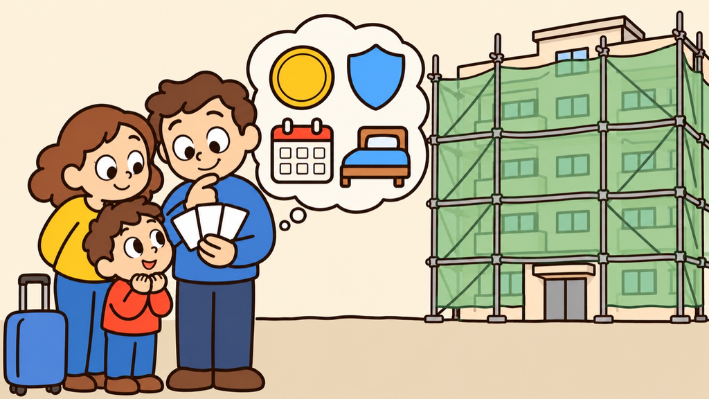

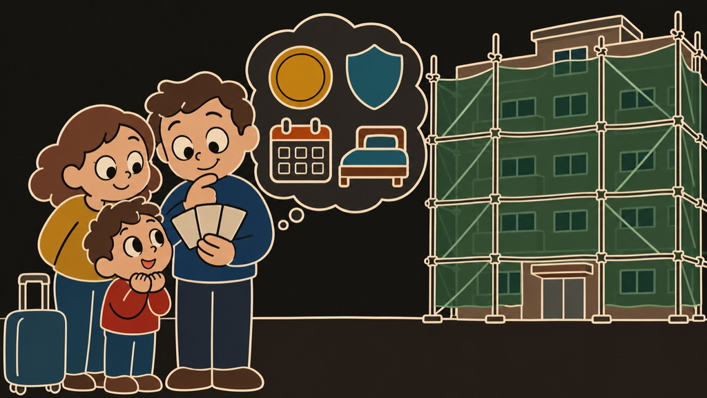

Our family of three may need furnished temporary housing in New York City for about six weeks **while our apartment is repaired**.

… Airbnb/Vrbo, an extended-stay hotel, corporate housing, or a short sublet?

… how should we compare the real costs, safety, cancellation risk, space, location, and day-to-day practicality,

… especially **with a child** and remote work needs?

Eight things asked at once, in one paragraph.

## Retrieval

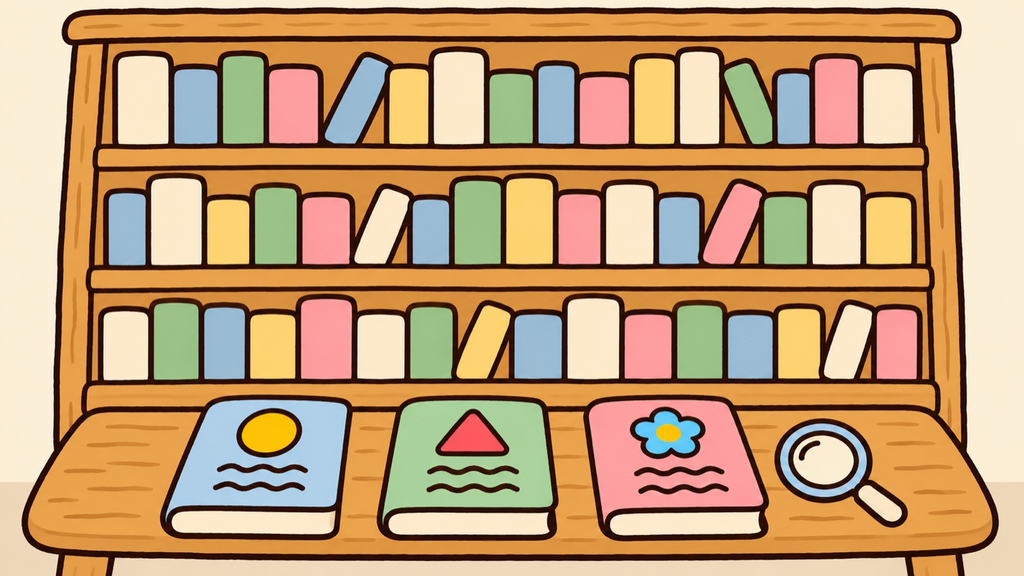

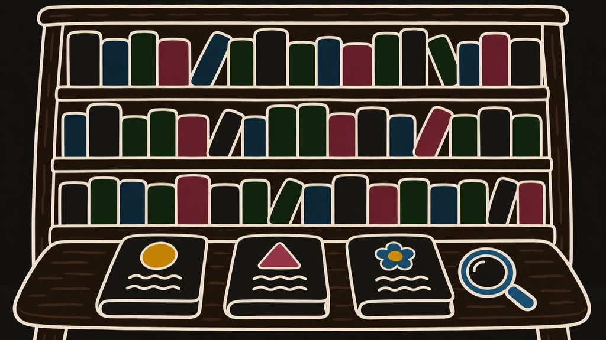

## Planning: how it works

[figure not shown]

## Planning: this request

The example · 8 subnarratives created for this one request

What options exist?

How do the four types compare?

Which listings are illegal?

What does it really cost?

Is it safe for a child?

What if we cancel?

Is there room to work?

Is the location practical?

## The queries each angle became

**What options exist?**

`furnished temporary housing New York City family three six weeks` `short term furnished rental NYC family child`

**How do the four types compare?**

`Airbnb vs extended stay hotel vs corporate housing vs sublet comparison` `short term rental types NYC family advantages disadvantages`

Two of the eight — the other six look the same, and all of them are in the appendix.

## Searching: how it works

[figure not shown]

## Reranking: a document becomes passages

[figure not shown]

## Nuggets: what the writer is given

[figure not shown]

## Answer Generation

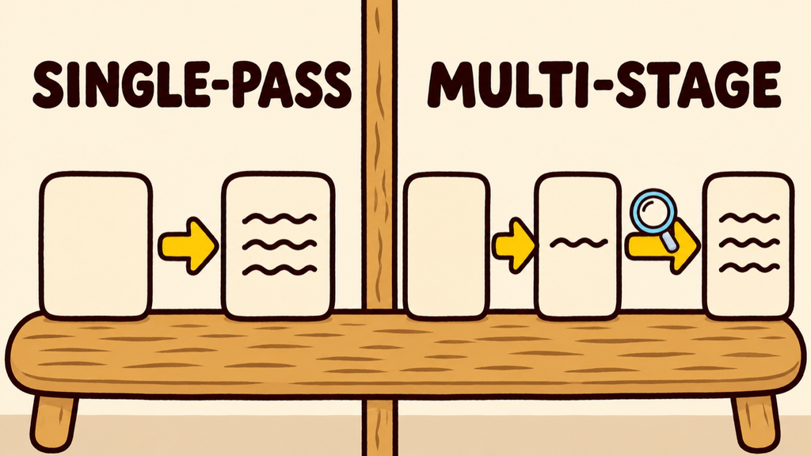

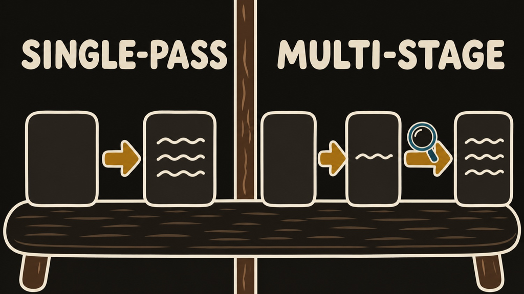

## Single-pass: Sol alone

[figure not shown]

## Multi-stage: the work changes hands

[figure not shown]

## The two places Luna is used

[figure not shown]

## Single-pass vs multi-stage

The example · rag2026-18

Single-pass · Sol alone **22 statements · 504 words**

504 words of the 1,024-word ceiling

Multi-stage · Luna and Sol **38 statements · 800 words**

800 words of the 1,024-word ceiling

plans*→*drafts*→*audits*→*revises*→*screens

Same evidence, same ceiling. Multi-stage made **16 more statements**.

## Results

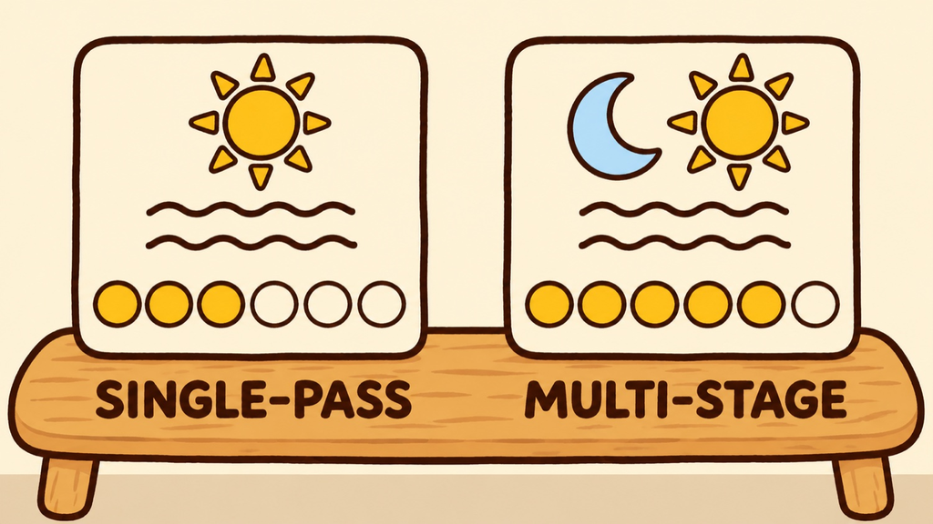

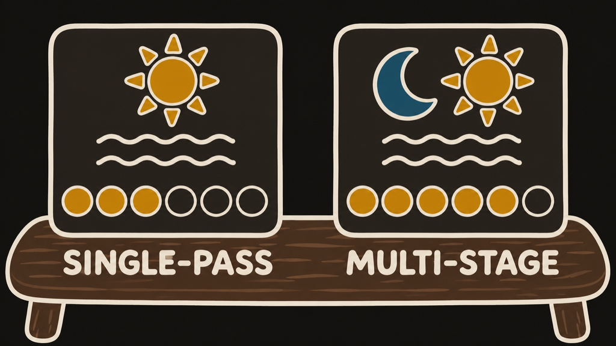

## What the organizers said about rag2026-18

One topic of the 42 — not the overall result

[figure not shown]

## Nugget coverage, all 42 scored topics

[figure not shown]

On rag2026-18 multi-stage wrote: *“if the apartment repairs involve **lead hazards**, ask whether the temporary unit has been made lead-safe.”*

The request said *repairs* and *a child* in different sentences. “Lead” never appears in the single-pass answer.

## When the two measures disagree

A different topic · rag2026-13, a founder scaling a startup

[figure not shown]

## How often they disagree

[figure not shown]

## Overall: 42 scored topics

[figure not shown]

## What the second pass cost

Model calls across all 119 requests

[figure not shown]

## Where that leaves the architecture

[figure not shown]

## Everything here is public

Per-topic scores [Organizer Score Explorer](https://npatta01.github.io/trec_rag_2026/reports/2026-organizer-score-explorer.html)

All 530 released rows, filterable.

The full trace [Retrieval Quality Analysis](https://npatta01.github.io/trec_rag_2026/reports/2026-retrieval-nugget-coverage.html) · [per-topic trace CSV](https://github.com/npatta01/trec_rag_2026/releases/tag/trec-rag-2026-artifacts-v1)

Every subnarrative, query and nugget, all 119 topics.

Both answers, judged [rag26-ss1](https://npatta01.github.io/trec_rag_2026/reports/2026-ragdoll-rag26-ss1.html) · [rag26-ms1-final](https://npatta01.github.io/trec_rag_2026/reports/2026-ragdoll-rag26-ms1-final.html)

Per-citation support judgments.

How it was built [Architecture walkthrough](https://npatta01.github.io/trec_rag_2026/reports/2026-competition-architecture.html) · [project hub](https://npatta01.github.io/trec_rag_2026/)

All of it lives in one place

github.com/npatta01/trec_rag_2026

This deck, the pipeline code, every report above, and the per-topic traces. rag2026-18 and rag2026-13 run all the way through, so the whole path is checkable.

## Appendix

The Retrieval submission — a separate, weaker run, kept back here for questions.

## The Retrieval submission

[figure not shown]

## How the Retrieval run scored

[figure not shown]

## Appendix · query lanes 1–4

rag2026-18 · 8 subnarratives × 2 queries = 16, plus the untouched request = 17

**What options exist?**

`furnished temporary housing New York City family three six weeks` `short term furnished rental NYC family child`

**How do the four types compare?**

`Airbnb vs extended stay hotel vs corporate housing vs sublet comparison` `short term rental types NYC family advantages disadvantages`

**Which listings are illegal?**

`illegal short term rental NYC avoid scams` `unreliable temporary housing New York City red flags`

**What does it really cost?**

`real cost comparison short term rental NYC fees taxes` `hidden costs temporary housing New York City`

## Appendix · query lanes 5–8

**Is it safe for a child?**

`safety family short term rental New York City neighborhood` `child safe temporary housing NYC`

**What if we cancel?**

`cancellation policy short term rental NYC` `flexible cancellation temporary housing New York City`

**Is there room to work?**

`space family short term rental NYC one bedroom` `temporary housing space child remote work New York City`

**Is the location practical?**

`location convenience short term rental NYC public transit` `temporary housing near work school New York City`

## Appendix · what this was built on

Every model and tool, with where to find it

Ours

planning**deepseek-v4-flash** · [deepseek.com](https://www.deepseek.com/) search**Pyserini** BM25 · Lin et al., SIGIR 2021 · 10.1145/3404835.3463238 reranking**mxbai-rerank-base-v2** · [mixedbread-ai on Hugging Face](https://huggingface.co/mixedbread-ai/mxbai-rerank-base-v2) dedup**all-MiniLM-L6-v2** · Reimers & Gurevych, EMNLP 2019 · [sentence-transformers](https://huggingface.co/sentence-transformers/all-MiniLM-L6-v2) writing**gpt-5.6-sol** and **gpt-5.6-luna**

The organizers’

nuggets**AutoNuggetizer** · [arXiv:2411.09607](https://arxiv.org/abs/2411.09607) · 10.1145/3726302.3730090 preferences**arena-rank**, Bradley–Terry · lmarena/arena-rank corpus**ClimbMix**, reachable only through the hosted BM25 endpoint scoringrubric and nugget assignment with GPT-6.1 Sol, per the organizers’ README

The three judged collections on the coverage slide are the organizers’ own: human rubrics, human-authored nuggets, and AutoNuggetizer’s generated ones.